# Notebook

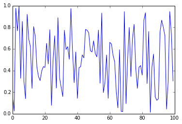

```python
import pandas as pd
pd.set_option('max_columns', 30)
pd.set_option('max_rows',20)
%pylab inline
import numpy as np
import matplotlib as mp
%matplotlib inline

import matplotlib.pyplot as plt
import numpy as np

import statsmodels.api as sm
from patsy import dmatrices
from sklearn.linear_model import LogisticRegression
from sklearn.cross_validation import train_test_split
from sklearn import metrics
from sklearn.cross_validation import cross_val_score
from scipy.stats.stats import pearsonr
from scipy.stats.stats import spearmanr


plt.plot(np.random.rand(100));
```

```python
# read in the survey data from excel file
xls = pd.ExcelFile('/user_home/w_frankwir/nsduh_mod.xlsx')
df = xls.parse('nsduh_mod', index_col=None, na_values=['NA'])
df1=df.copy()
print df1.CIG30USE.describe()
```

```
count    18856.000000
mean        46.728468
std         35.607659
min          1.000000
25%         20.000000
50%         30.000000
75%         91.000000
max         93.000000
Name: CIG30USE, dtype: float64
```

```python
# fulfill missing values by replacing numeric zeros to logic values
df1.MJYRTOT=df1.MJYRTOT.replace(991,0)
df1.MJDAY30A=df1.MJDAY30A.replace(91,0)
df1.MJDAY30A=df1.MJDAY30A.replace(93,0)
df1.MJREC=df1.MJREC.replace(91,0)
df1.MR30EST=df1.MR30EST.replace(91,0)
df1.MR30EST=df1.MR30EST.replace(93,0)
```

```python
df1.CIGREC=df1.CIGREC.replace(91,0)
df1.CIG30USE=df1.CIG30USE.replace(91,0)
df1.CIG30USE=df1.CIG30USE.replace(93,0)
df1.CG30EST=df1.CG30EST.replace(91,0)
df1.CG30EST=df1.CG30EST.replace(93,0)
df1.CIG30AV=df1.CIG30AV.replace(91,0)
df1.CIG30AV=df1.CIG30AV.replace(93,0)
# df1=df1.replace(91,np.nan)# df1=df1.replace(91,np.nan)
# df1=df1.replace(93,np.nan)
```

```python
# look at the summary by describing and QA the data
print df1.describe()
df1.groupby('IRSEX').mean()
```

```
             CASEID         QUESTID2        CIGREC       CG30EST  \
count  18856.000000     18856.000000  18856.000000  18856.000000
mean   27492.546988  54154381.245121      0.958634      2.876167
std    15901.718379  25575165.548453      0.604401      2.642671
min        1.000000  10014955.000000      0.000000      0.000000
25%    13738.750000  31856038.000000      1.000000      0.000000
50%    27331.000000  53711622.000000      1.000000      2.000000
75%    41231.250000  75785812.250000      1.000000      6.000000
max    55150.000000  99995349.000000      2.000000      6.000000

            CIG30AV         IRSEX        CATAG3      NEWRACE2      EDUCCAT2  \
count  18856.000000  18856.000000  18856.000000  18856.000000  18856.000000
mean       2.130993      1.481226      2.474491      2.400138      2.854105
std        1.944257      0.499661      1.148708      2.272942      1.298422
min        0.000000      1.000000      1.000000      1.000000      1.000000
25%        0.000000      1.000000      2.000000      1.000000      2.000000
50%        2.000000      1.000000      2.000000      1.000000      3.000000
75%        4.000000      2.000000      3.000000      2.000000      4.000000
max        7.000000      2.000000      5.000000      7.000000      5.000000

            HEALTH2        CGUSER         MJREC       MJYRTOT      MJDAY30A  \
count  18856.000000  18856.000000  18856.000000  18856.000000  18856.000000
mean       2.309185      0.795821      0.769941     62.301389      4.392872
std        0.912550      0.403111      0.794906    110.108528      9.066862
min        1.000000      0.000000      0.000000      0.000000      0.000000
25%        2.000000      1.000000      0.000000      0.000000      0.000000
50%        2.000000      1.000000      1.000000      2.000000      0.000000
75%        3.000000      1.000000      1.000000     60.000000      2.000000
max        4.000000      1.000000      2.000000    365.000000     30.000000

            MR30EST        MJUSER         MJDEP      CIG30USE
count  18856.000000  18856.000000  18856.000000  18856.000000
mean       1.101718      0.542586      0.080452     13.006576
std        1.932635      0.498196      0.271999     13.537030
min        0.000000      0.000000      0.000000      0.000000
25%        0.000000      0.000000      0.000000      0.000000
50%        0.000000      1.000000      0.000000      5.000000
75%        1.000000      1.000000      0.000000     30.000000
max        6.000000      1.000000      1.000000     30.000000
```

| IRSEX | CASEID | QUESTID2 | CIGREC | CG30EST | CIG30AV | CATAG3 | NEWRACE2 | EDUCCAT2 | HEALTH2 | CGUSER | MJREC | MJYRTOT | MJDAY30A | MR30EST | MJUSER | MJDEP | CIG30USE |
| --- | --- | --- | --- | --- | --- | --- | --- | --- | --- | --- | --- | --- | --- | --- | --- | --- | --- |
| 1 | 27537.776528 | 53710136.110202 | 0.961869 | 2.857698 | 2.168473 | 2.463504 | 2.464936 | 2.795236 | 2.272644 | 0.800245 | 0.802085 | 75.545798 | 5.396034 | 1.314148 | 0.578818 | 0.096708 | 12.815171 |
| 2 | 27443.788406 | 54633288.662993 | 0.955147 | 2.896077 | 2.090588 | 2.486335 | 2.330284 | 2.917567 | 2.348578 | 0.791051 | 0.735288 | 48.023584 | 3.311439 | 0.872713 | 0.503527 | 0.062927 | 13.212916 |

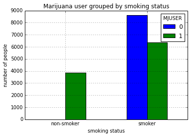

```python
_ = pd.crosstab(df1.CGUSER, df1.MJUSER.astype(int)).plot(kind='bar')
plt.title('Marijuana user grouped by smoking status')
plt.xlabel('smoking status')
plt.ylabel('number of people')
xm=[0,1]
LABELS = ["non-smoker", "smoker"]
_ = plt.xticks(xm, LABELS, rotation='horizontal')
```

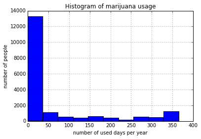

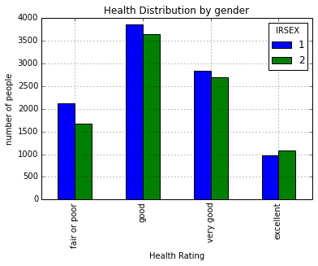

```python
# plotting data - histogram, bar, scatter, box charts etc.

_= df1.MJYRTOT.hist()
plt.title('Histogram of marijuana usage')
plt.xlabel('number of used days per year')
plt.ylabel('number of people')

_ = pd.crosstab(df1.HEALTH2, df1.IRSEX.astype(int)).plot(kind='bar')
plt.title('Health Distribution by gender')
plt.xlabel('Health Rating')
plt.ylabel('number of people')
xm=[0,1,2,3]
LABELS = ["fair or poor", "good", "very good","excellent"]
_ = plt.xticks(xm, LABELS)
```

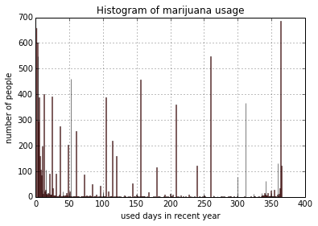

```python
# browse drug usage situtation
dfmf = df1.loc[(df1["MJUSER"]==1) & (df1["MJYRTOT"]>0)]
_= dfmf.MJYRTOT.hist(color='r', alpha=0.5, bins=365)
plt.title('Histogram of marijuana usage')
plt.xlabel('used days in recent year')
plt.ylabel('number of people')
```

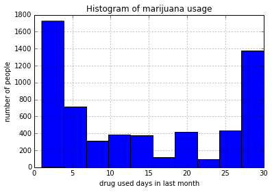

```python
df5= df1.loc[(df1["MJDAY30A"] > 0)]
_= df5.MJDAY30A.hist()
plt.title('Histogram of marijuana usage')
plt.xlabel('drug used days in last month')
plt.ylabel('number of people')
```

```python
# pull smoker population
# plotting the data to browse the drug usage status
# Check the distribution across educational level
dfsm = df1.loc[(df1["CGUSER"]==1)]
dfsm['EDUCCAT2'] = dfsm['EDUCCAT2'].map({1:'< high school', 2:'= high school', 3:'college', 4:'college grd', 5:'12-17 old'})
print pd.crosstab(dfsm.EDUCCAT2, dfsm.MJUSER.astype(int)).apply(lambda c: c/c.sum(), axis=1)
```

```
MJUSER                0         1
EDUCCAT2
12-17 old      0.359228  0.640772
< high school  0.607858  0.392142
= high school  0.624326  0.375674
college        0.588600  0.411400
college grd    0.597513  0.402487
```

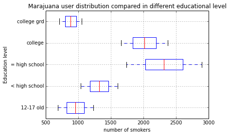

```python
#dfsm = df1.loc[(df1["CGUSER"]==1)]
#_= dfsm.MJUSER.hist()
# across the educational level
barlist = pd.crosstab(dfsm.MJUSER, dfsm.EDUCCAT2.astype(str)).plot(kind='box',  vert=False)
plt.title('Marajuana user distribution compared in different educational level')
plt.ylabel('Education level')
plt.xlabel('number of smokers')
```

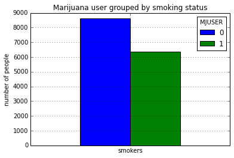

```python
_ = pd.crosstab(dfsm.CGUSER, dfsm.MJUSER.astype(int)).plot(kind='bar')
plt.title('Marijuana user grouped by smoking status')
plt.xlabel('')
plt.ylabel('number of people')
xm=[0]
LABELS = ["smokers"]
_ = plt.xticks(xm, LABELS,rotation='horizontal')
```

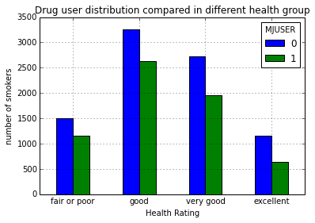

```python
# across the health level
_ = pd.crosstab(dfsm.HEALTH2, dfsm.MJUSER.astype(int)).plot(kind='bar')
plt.title('Drug user distribution compared in different health group')
plt.xlabel('Health Rating')
plt.ylabel('number of smokers')
xm=[0,1,2,3]
LABELS = ["fair or poor", "good", "very good","excellent"]
_ = plt.xticks(xm, LABELS, rotation="horizontal")
```

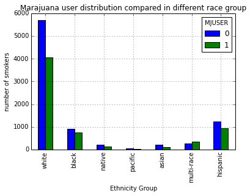

```python
#dfsm = df1.loc[(df1["CGUSER"]==1)]
#_= dfsm.MJUSER.hist()
#across the race group
_ = pd.crosstab(dfsm.NEWRACE2, dfsm.MJUSER.astype(int)).plot(kind='bar')
plt.title('Marajuana user distribution compared in different race group')
plt.xlabel('Ethnicity Group')
plt.ylabel('number of smokers')
xm=[0,1,2,3,4,5,6]
LABELS = ["white", "black", "native", "pacific", "asian", "multi-race","hispanic"]
_ = plt.xticks(xm, LABELS)
```

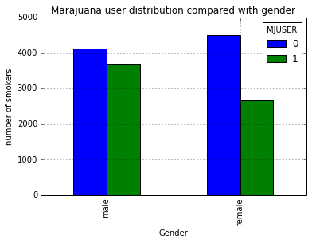

```python
#print pd.crosstab(dfsm.NEWRACE2, dfsm.MJUSER.astype(int)).apply(lambda c: c/c.sum(), axis=1)
_ = pd.crosstab(dfsm.IRSEX, dfsm.MJUSER.astype(int)).plot(kind='bar')
plt.title('Marajuana user distribution compared with gender')
plt.xlabel('Gender')
plt.ylabel('number of smokers')
xm=[0,1]
LABELS = ["male", "female"]
_ = plt.xticks(xm, LABELS)
```

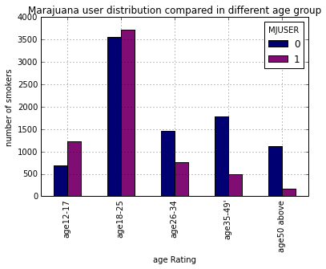

```python
#dfsm = df1.loc[(df1["CGUSER"]==1)]
#_= dfsm.MJUSER.hist()
#across the age group
my_colors = [(x/2.0, x/20.0, 0.45) for x in range(len(dfsm))]
_ = pd.crosstab(dfsm.CATAG3, dfsm.MJUSER.astype(int)).plot(kind='bar', color=my_colors)
plt.title('Marajuana user distribution compared in different age group')
plt.xlabel('age Rating')
plt.ylabel('number of smokers')
xm=[0,1,2,3,4]
LABELS = ["age12-17", "age18-25", "age26-34","age35-49'","age50 above"]
_ = plt.xticks(xm, LABELS)
```

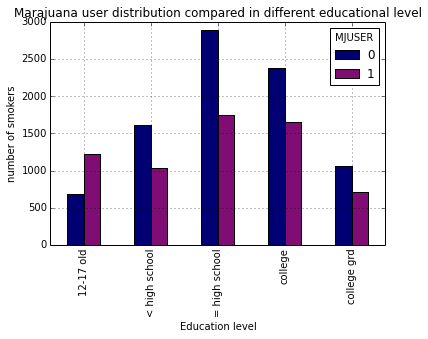

```python
#dfsm = df1.loc[(df1["CGUSER"]==1)]
#_= dfsm.MJUSER.hist()
#across the health level
#print len(dfsm)
my_colors = [(x/2.0, x/20.0, 0.45) for x in range(len(dfsm))]
barlist = pd.crosstab(dfsm.EDUCCAT2, dfsm.MJUSER.astype(int)).plot(kind='bar', color=my_colors)
plt.title('Marajuana user distribution compared in different educational level')
plt.xlabel('Education level')
plt.ylabel('number of smokers')
```

```python
# plotting the data
# Drug dependence distribution across the smokers
criterion = df1['MJUSER'].map(lambda x: x==1)
dft=df1[criterion]
dft['MJDEP'] = df1['MJDEP'].map({1:'drug dependence', 0:'none drug dependence'})
dft['CGUSER'] = df1['CGUSER'].map({1:'smoker', 0:'none smoker'})
print pd.crosstab(dft.CGUSER, dft.MJDEP.astype(str)).apply(lambda c: c/c.sum(), axis=1)
print pd.crosstab(dft.CGUSER, dft.MJDEP)
# result shows that smokers are more likely turning into drug dependence than non-smokers
```

```
MJDEP        drug dependence  none drug dependence
CGUSER
none smoker         0.112987              0.887013
smoker              0.169566              0.830434
MJDEP        drug dependence  none drug dependence
CGUSER
none smoker              435                  3415
smoker                  1082                  5299
```

In the summary statistics above, it's showing that more than 45% of drug users are smokers, which makes us to think about if smoking may have any impacts on using the drug, as well as drives the drug user turning into Marijuana dependence. The above results are showing 11% of non-smokers are drug dependent while it's 17% in smoking group.

```python
_ = pd.crosstab(df1.CGUSER, df1.MJUSER.astype(int)).plot(kind='bar')
plt.title('Marijuana user grouped by smoking status')
plt.xlabel('smoking status')
plt.ylabel('number of people')
xm=[0,1]
LABELS = ["non-smoker", "smoker"]
_ = plt.xticks(xm, LABELS)
```

[output not shown]

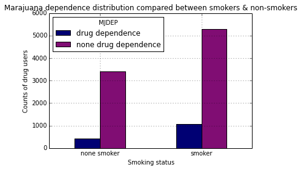

```python
# plotting the above crosstab with bar chart
my_colors = [(x/2.0, x/20.0, 0.45) for x in range(len(dft))]
barlist = pd.crosstab(dft.CGUSER, dft.MJDEP.astype(str)).plot(kind='bar', color=my_colors)
plt.title('Marajuana dependence distribution compared between smokers & non-smokers')
plt.xlabel('Smoking status')
plt.ylabel('Counts of drug users')
plt.xticks(rotation="horizontal")
```

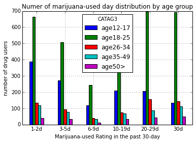

```python
# check the most recent Majrijuana users who have used drugs in the past 30 days
# across the age group
df4= df1.loc[(df1["MJUSER"] == 1) & (df1["MR30EST"] > 0)]
plot1 = pd.crosstab(df4.MR30EST, df4.CATAG3.map({1:'age12-17', 2:'age18-25',3:'age26-34',4:'age35-49',5:'age50>'})).plot(kind='bar')
plt.title('Numer of marijuana-used day distribution by age group')
plt.xlabel('Marijuana-used Rating in the past 30-day')
plt.ylabel('number of drug users')
xm=[0,1,2,3,4,5]
LABELS = ["1-2d", "3-5d", "6-9d", "10-19d","20-29d","30d"]
_ = plt.xticks(xm, LABELS,rotation="horizontal")
from matplotlib.font_manager import FontProperties
fontP = FontProperties()
fontP.set_size('small')
#legend([plot1], "upper right", prop = fontP)
plt.show()
```

```python
# for categorical predictors, dummy variables need to be created. i.e. health condition
dummy_health=pd.get_dummies(df1['HEALTH2'],prefix='health')
print dummy_health.head()
cols_to_keep = ['IRSEX', 'MJREC', 'MJYRTOT', 'MJDEP']
df2 = df1[cols_to_keep].join(dummy_health.ix[:, 'health_2':])
print df2.head()
```

```
   health_1  health_2  health_3  health_4
0         1         0         0         0
1         1         0         0         0
2         0         1         0         0
3         0         0         1         0
4         1         0         0         0
   IRSEX  MJREC  MJYRTOT  MJDEP  health_2  health_3  health_4
0      1      0        0      0         0         0         0
1      1      1      365      0         0         0         0
2      1      0        0      0         1         0         0
3      1      0        0      0         0         1         0
4      1      0        0      0         0         0         0
```

```python
# select the sample data which are the drug users
criterion = df1['MJUSER'].map(lambda x: x==1)
df3=df1[criterion]
print df3.head()
```

```
    CASEID  QUESTID2  CIGREC  CG30EST  CIG30AV  IRSEX  CATAG3  NEWRACE2  \
1        2  88530883       2        0        0      1       2         1
5        9  67182690       1        5        3      1       2         1
6       11  69818657       1        1        2      1       2         7
9       20  81923978       1        5        3      1       2         1
10      21  41568573       1        5        3      2       2         2

    EDUCCAT2  HEALTH2  CGUSER  MJREC  MJYRTOT  MJDAY30A  MR30EST  MJUSER  \
1          2        1       1      1      365        30        6       1
5          3        2       1      2       24         0        0       1
6          2        4       1      1      236        25        5       1
9          3        2       1      1      208        25        5       1
10         3        3       1      2        5         0        0       1

    MJDEP  CIG30USE
1       0         0
5       1        20
6       0         2
9       0        20
10      0        21
```

```python
df3.count()
#import scipy as sp
#cg30a = df3['CIG30USE'].values
#cumfreqs, lowlim, binsize, extrapoints = sp.stats.cumfreq(cg30a, numbins=4)
#cumfreqs
#df3['MR30EST'].value_counts()
```

```
CASEID      10231
QUESTID2    10231
CIGREC      10231
CG30EST     10231
CIG30AV     10231
IRSEX       10231
CATAG3      10231
NEWRACE2    10231
EDUCCAT2    10231
HEALTH2     10231
CGUSER      10231
MJREC       10231
MJYRTOT     10231
MJDAY30A    10231
MR30EST     10231
MJUSER      10231
MJDEP       10231
CIG30USE    10231
dtype: int64
```

```python
# set a model only having drug used frequency and continuity for test
y, X = dmatrices('MJDEP ~ C(CATAG3) + MJYRTOT + MJDAY30A',
                  df3, return_type="dataframe")
print X.columns
```

```
Index([u'Intercept', u'C(CATAG3)[T.2]', u'C(CATAG3)[T.3]', u'C(CATAG3)[T.4]', u'C(CATAG3)[T.5]', u'MJYRTOT', u'MJDAY30A'], dtype='object')
```

```python
X = X.rename(columns = {'C(CATAG3)[T.2]':'age18-25',
                        'C(CATAG3)[T.3]':'age26-34',
                        'C(CATAG3)[T.4]':'age35-49',
                        'C(CATAG3)[T.5]':'age50 above'})
```

```python
y = np.ravel(y)
# instantiate a logistic regression model, and fit with X and y
model = LogisticRegression()
model = model.fit(X, y)
# check the accuracy on the training set
model.score(X, y)
```

```
0.84879288437102918
```

```python
import statsmodels.api as sm
mdep=sm.Logit(y, X).fit()
print mdep.summary()
```

```
Optimization terminated successfully.
         Current function value: 0.382700
         Iterations 7
                           Logit Regression Results
==============================================================================
Dep. Variable:                      y   No. Observations:                10231
Model:                          Logit   Df Residuals:                    10224
Method:                           MLE   Df Model:                            6
Date:                Sat, 01 Aug 2015   Pseudo R-squ.:                 0.08817
Time:                        07:53:12   Log-Likelihood:                -3915.4
converged:                       True   LL-Null:                       -4294.0
                                        LLR p-value:                2.724e-160
===============================================================================
                  coef    std err          z      P>|z|      [95.0% Conf. Int.]
-------------------------------------------------------------------------------
Intercept      -1.7437      0.056    -31.087      0.000        -1.854    -1.634
age18-25       -0.8486      0.066    -12.931      0.000        -0.977    -0.720
age26-34       -1.4712      0.124    -11.822      0.000        -1.715    -1.227
age35-49       -1.5412      0.147    -10.496      0.000        -1.829    -1.253
age50 above    -1.3967      0.205     -6.806      0.000        -1.799    -0.994
MJYRTOT         0.0053      0.000     15.024      0.000         0.005     0.006
MJDAY30A       -0.0045      0.004     -1.124      0.261        -0.012     0.003
===============================================================================
```

```python
#print mdep.params
#print pd.DataFrame(zip(X.columns, np.transpose(model.coef_)))
```

```python
#run pearson test for correlation between frequency and continuity
#which are highly correlated
#thus it will not be appropriate to plug them both in the model
pearsonr(df3['MJYRTOT'].values, df3['MJDAY30A'].values)
```

```
(0.8137008704301848, 0.0)
```

```python
# generate data for plotting scatter plot by clasifing the dependence target
# with drug dependence
dep_tot = df3[df3['MJDEP'] == 1]['MJYRTOT'].values
dep_30a = df3[df3['MJDEP'] == 1]['MJDAY30A'].values
dep_cg30a = df3[df3['MJDEP'] == 1]['CIG30USE'].values
dep_age = df3[df3['MJDEP'] == 1]['CATAG3'].values
#dep_tot[:3]
```

```python
# without drug dependence
ndep_tot = df3[df3['MJDEP'] == 0]['MJYRTOT'].values
ndep_30a = df3[df3['MJDEP'] == 0]['MJDAY30A'].values
ndep_cg30a = df3[df3['MJDEP'] == 0]['CIG30USE'].values
ndep_age = df3[df3['MJDEP'] == 0]['CATAG3'].values
#ndep_age[:10]
```

```python
# generate the seperation line for dividing target domains - drug dependence and non-dependence
logit_pars = mdep.params
intercept = -logit_pars['Intercept'] / logit_pars['MJYRTOT']
slope = -logit_pars['MJDAY30A'] / logit_pars['MJYRTOT']
```

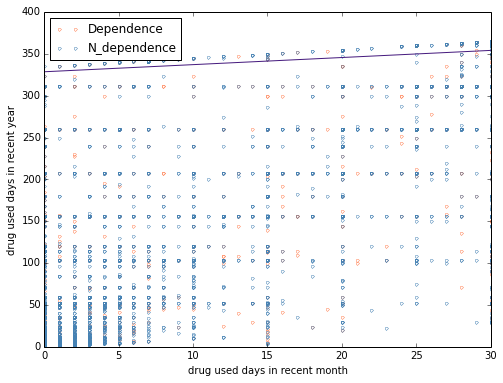

```python
fig = plt.figure(figsize = (8, 6))
# dependence in coral
plt.plot(dep_30a, dep_tot, '.', label = 'Dependence',mfc = 'None', mec='coral', alpha = .4)
# none-dependence in blue
plt.plot(ndep_30a, ndep_tot, '.', label = 'N_dependence',mfc = 'None', mec='steelblue', alpha = .4)
# The separating line
_ = plt.plot(array([0, 30]), intercept + slope * array([0, 30]),'-', color = '#461B7E')
plt.xlabel('drug used days in recent month')
plt.ylabel('drug used days in recent year')
plt.legend(loc='upper left')
#the scatter plot shows that the drug users are not evenly distributed across measures.
#more users are exposed with either light or much heavy usage across the year and month.
```

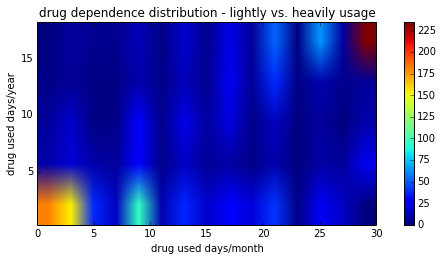

```python
# generate the heatmap to show the drug usage days in month/year pairs
# note that the population includes drug users who have zero consumptions in recent month
# the total days per year (y axis) is scaled
dep_tot1 = (1/20.) * dep_tot
heatmap, xedges, yedges = np.histogram2d(dep_30a, dep_tot1, bins=(5,15))
extent = [xedges[0], xedges[-1], yedges[0], yedges[-1]]
#fig = plt.figure()
fig = plt.figure(figsize = (10, 8) , dpi=80, facecolor='w', edgecolor='k')
ax2 = fig.add_subplot(212)
t = ax2.imshow(heatmap, extent = extent,origin='lower')
cbar = plt.colorbar(t)
plt.xlabel('drug used days/month',fontsize=10)
plt.ylabel('drug used days/year',fontsize=10)
plt.title('drug dependence distribution - lightly vs. heavily usage')
plt.show()

#fig.savefig('heatmap.png')
```

```python
# Before combine smoking measure with drug usage in the same model, the related data are plotted:
# generate the heatmap to show the drug used days/year vs. smoking days/month
# note that the population excludes drug users who have zero cigarette consumptions in recent month
# the total drug used days per year (y axis) is scaled
# generate data for plotting scatter plot by clasifing the dependence target

# 1. dependence
dep1_tot = df3[(df3['MJDEP'] == 1) & (df3['CIG30USE']>0) & (df3['MJYRTOT']>0)]['MJYRTOT'].values
dep1_cg30a = df3[(df3['MJDEP'] == 1) & (df3['CIG30USE']>0 & (df3['MJYRTOT']>0))]['CIG30USE'].values

# 2.non-dependence
ndep1_tot = df3[(df3['MJDEP'] == 0) & (df3['CIG30USE']>0 & (df3['MJYRTOT']>0))]['MJYRTOT'].values
ndep1_cg30a = df3[(df3['MJDEP'] == 0) & (df3['CIG30USE']>0 & (df3['MJYRTOT']>0))]['CIG30USE'].values
```

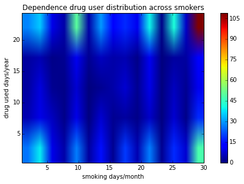

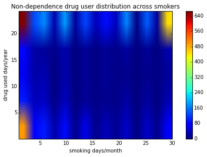

```python
# drug dependence cases
dep1_tot2 = (1/15.) * dep1_tot
heatmap, xedges, yedges = np.histogram2d(dep1_cg30a, dep1_tot2, bins=(5,15))
extent = [xedges[0], xedges[-1], yedges[0], yedges[-1]]
#fig = plt.figure()
fig = plt.figure(figsize = (10, 10) , dpi=80, facecolor='w', edgecolor='k')
ax2 = fig.add_subplot(211)
t = ax2.imshow(heatmap, extent = extent,origin='lower')
cbar = plt.colorbar(t)
plt.xlabel('smoking days/month',fontsize=10)
plt.ylabel('drug used days/year',fontsize=10)
plt.title('Dependence drug user distribution across smokers')

# non-dependence cases
ndep1_tot2 = (1/15.) * ndep1_tot
heatmap, xedges, yedges = np.histogram2d(ndep1_cg30a, ndep1_tot2, bins=(5,15))
extent = [xedges[0], xedges[-1], yedges[0], yedges[-1]]
fig = plt.figure(figsize = (10, 10) , dpi=80, facecolor='w', edgecolor='k')
ax2 = fig.add_subplot(212)
t = ax2.imshow(heatmap, extent = extent,origin='lower')
cbar = plt.colorbar(t)
plt.xlabel('smoking days/month',fontsize=10)
plt.ylabel('drug used days/year',fontsize=10)
plt.title('Non-dependence drug user distribution across smokers')
plt.show()
```

It's observed that the area at the lower bottom represents a controlled drug usage group - the baseline. In the plot for dependence cases, it shows that among those ones who have controlled marijuana usage, more drug dependent cases came from the smoking groups with either light or much heavy tobacco consumption. While in the plot for non-dependence case, except the light smoking group, the cases are evenly distributed across the other level of groups.

The area at the upper top represents relatively heavier marijuana usage. It's not evenly distributed across different smoking groups. Lighter smokers own more non-dependent cases than heavier smokers. However, the more regular smokers (above 25 smoking days per month) also own more non-dependent cases than smokers with medium cigarette consumptions.

```python
# Drug user distribution across the smokers shown in crosstab
df31=df3[['MJDEP','CG30EST']]
df31['MJDEP'] = df31['MJDEP'].map({1:'drug dependence', 0:'none drug dependence'})
df31['CG30EST'] = df31['CG30EST'].map({0:'1. 0 days', 1:'2. 1-2 days', 2:'3. 3-5 days',3:'4. 6-9 days',
                                       4:'5. 10-19 days',5:'6. 20-29 days',6:'7. all 30 days'})
#print pd.crosstab(df31.CG30EST, df31.MJDEP.astype(str)).apply(lambda c: c/c.sum(), axis=1)
# print pd.crosstab(df31.MJDEP, df31.CG30EST)
res = pd.crosstab(df31.MJDEP, df31.CG30EST)
res.astype('float').div(res.sum(axis=1)/100., axis=0)
```

| CG30EST MJDEP | 1. 0 days | 2. 1-2 days | 3. 3-5 days | 4. 6-9 days | 5. 10-19 days | 6. 20-29 days | 7. all 30 days |
| --- | --- | --- | --- | --- | --- | --- | --- |
| drug dependence | 42.254450 | 7.778510 | 8.042189 | 3.427818 | 7.646671 | 9.228741 | 21.621622 |
| none drug dependence | 52.065641 | 6.828093 | 4.980491 | 1.801698 | 5.301813 | 6.334634 | 22.687629 |

```python
res.astype('float').div(res.sum(axis=0)/100., axis=1)
```

| CG30EST MJDEP | 1. 0 days | 2. 1-2 days | 3. 3-5 days | 4. 6-9 days | 5. 10-19 days | 6. 20-29 days | 7. all 30 days |
| --- | --- | --- | --- | --- | --- | --- | --- |
| drug dependence | 12.379297 | 16.54979 | 21.942446 | 24.880383 | 20.069204 | 20.231214 | 14.229935 |
| none drug dependence | 87.620703 | 83.45021 | 78.057554 | 75.119617 | 79.930796 | 79.768786 | 85.770065 |

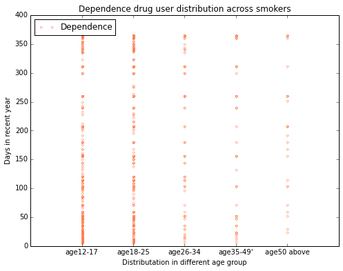

```python
# Drug dependence distribution across age groups
fig = plt.figure(figsize = (8, 6))
# dependence in coral
plt.plot(dep_age, dep_tot, '.', label = 'Dependence',mfc = 'None', mec='coral', alpha = .4)
#plt.plot(ndep_age, ndep_tot, '.', label = 'N_dependence',mfc = 'None', mec='steelblue', alpha = .4)
plt.xlim(0, 6)
plt.xlabel('Distributation in different age group')
plt.ylabel('Days in recent year')
plt.legend(loc='upper left')
xm=[1,2,3,4,5]
#map({1:'age12-17', 2:'age18-25', 3:'age26-34', 4:'age35-49', 5:'age50 above'})
LABELS = ["age12-17", "age18-25", "age26-34","age35-49'","age50 above"]
plt.xticks(xm, LABELS)
plt.title('Dependence drug user distribution across smokers')
plt.show()
```

```python
# Before plug in the smoking info, test a simple model with the drug usage info only
y, X = dmatrices('MJDEP ~ C(CATAG3) + MJYRTOT + C(MR30EST)',
                  df3, return_type="dataframe")
#print X.columns
```

```python
X = X.rename(columns = {'C(CATAG3)[T.2]':'age18-25',
                        'C(CATAG3)[T.3]':'age26-34',
                        'C(CATAG3)[T.4]':'age35-49',
                        'C(CATAG3)[T.5]':'age50 above'})
```

```python
X = X.rename(columns = {'C(MR30EST)[T.1]':'1 or 2 days',
                        'C(MR30EST)[T.2]':'3-5 days',
                        'C(MR30EST)[T.3]':'6-9 days',
                        'C(MR30EST)[T.4]':'10-19 days',
                        'C(MR30EST)[T.5]':'20-29 days',
                        'C(MR30EST)[T.6]':'all 30 days'})
```

```python
y = np.ravel(y)
# instantiate a logistic regression model, and fit with X and y
model = LogisticRegression()
model = model.fit(X, y)

# check the accuracy on the training set
#model.score(X, y)
```

```python
import statsmodels.api as sm
sm.Logit(y, X).fit().summary()
```

```
Optimization terminated successfully.
         Current function value: 0.380883
         Iterations 7
```

Logit Regression Results

| Dep. Variable: | y | No. Observations: | 10231 |
| --- | --- | --- | --- |
| Model: | Logit | Df Residuals: | 10219 |
| Method: | MLE | Df Model: | 11 |
| Date: | Sat, 01 Aug 2015 | Pseudo R-squ.: | 0.09250 |
| Time: | 09:29:01 | Log-Likelihood: | -3896.8 |
| converged: | True | LL-Null: | -4294.0 |
|  |  | LLR p-value: | 3.066e-163 |

|  | coef | std err | z | P>\|z\| | [95.0% Conf. Int.] |
| --- | --- | --- | --- | --- | --- |
| Intercept | -1.8660 | 0.067 | -27.997 | 0.000 | -1.997 -1.735 |
| age18-25 | -0.8386 | 0.066 | -12.738 | 0.000 | -0.968 -0.710 |
| age26-34 | -1.4502 | 0.124 | -11.650 | 0.000 | -1.694 -1.206 |
| age35-49 | -1.5291 | 0.147 | -10.414 | 0.000 | -1.817 -1.241 |
| age50 above | -1.3842 | 0.205 | -6.755 | 0.000 | -1.786 -0.983 |
| 1 or 2 days | 0.0556 | 0.107 | 0.519 | 0.604 | -0.155 0.266 |
| 3-5 days | 0.2553 | 0.109 | 2.342 | 0.019 | 0.042 0.469 |
| 6-9 days | 0.4636 | 0.138 | 3.368 | 0.001 | 0.194 0.733 |
| 10-19 days | 0.4415 | 0.110 | 4.017 | 0.000 | 0.226 0.657 |
| 20-29 days | 0.1176 | 0.117 | 1.003 | 0.316 | -0.112 0.347 |
| all 30 days | -0.1030 | 0.134 | -0.768 | 0.443 | -0.366 0.160 |
| MJYRTOT | 0.0051 | 0.000 | 14.284 | 0.000 | 0.004 0.006 |

```python
#print sm.Logit(y, X).fit().conf_int()
```

```python
# examine the coefficients
#pd.DataFrame(zip(X.columns, np.transpose(model.coef_)))
```

Before adding the smoking measure into the model, we need to: step 1. check the correlation matrix among user demographic variables, check covariance and select blocking factors step 2. check the correlation between drug usage and smoking step 3. check multicolinearity

```python
#compute pearson correlation
from itertools import imap

from itertools import imap

def pearsonr(x, y):
  # Assume len(x) == len(y)
  n = len(x)
  sum_x = float(sum(x))
  sum_y = float(sum(y))
  sum_x_sq = sum(map(lambda x: pow(x, 2), x))
  sum_y_sq = sum(map(lambda x: pow(x, 2), y))
  psum = sum(imap(lambda x, y: x * y, x, y))
  num = psum - (sum_x * sum_y/n)
  den = pow((sum_x_sq - pow(sum_x, 2) / n) * (sum_y_sq - pow(sum_y, 2) / n), 0.5)
  if den == 0: return 0
      return num / den
```

```python
# test correlation between MJ usage and Cig usage using spearman
mjest = df3['MR30EST'].values
c30av = df3['CIG30AV'].values
spearmanr(c30av, mjest)
```

```
(0.24343297096151154, 6.6252567242637645e-138)
```

```python
# test correlation between MJ usage and Cig usage using pearson
mjtot = df3['MJYRTOT'].values
cguse = df3['CIG30USE'].values
pearsonr(cguse, mjtot)
```

```
(0.26992192130820575, 2.7235384852226234e-170)
```

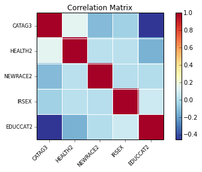

```python
# generate the coefficient matrix
from numpy import corrcoef, sum, log, arange
from numpy.random import rand
from pylab import pcolor, show, colorbar, xticks, yticks

dm=df3[['CATAG3','HEALTH2','NEWRACE2','IRSEX','EDUCCAT2']]
# plotting the correlation matrix
#R = corrcoef(dm)
corr_matrix = np.corrcoef(dm.transpose())
sm.graphics.plot_corr(corr_matrix, xnames=list(dm.columns.values))
plt.show()
```

```python
from numpy import corrcoef, sum, log, arange
from numpy.random import rand
from pylab import pcolor, show, colorbar, xticks, yticks

dc=df3[['MJYRTOT','MR30EST','MJDAY30A','CIG30AV','CIG30USE','CG30EST']]
dc1=dc[:100]
# plotting the correlation matrix
R = corrcoef(dc1)
print R
```

```
[[ 1.          0.68196064  0.9998267  ...,  0.974837    0.99700792
   0.99684303]
 [ 0.68196064  1.          0.67768745 ...,  0.8256913   0.73604588
   0.71021828]
 [ 0.9998267   0.67768745  1.         ...,  0.97277942  0.99654618
   0.99529664]
 ...,
 [ 0.974837    0.8256913   0.97277942 ...,  1.          0.98850631
   0.98318615]
 [ 0.99700792  0.73604588  0.99654618 ...,  0.98850631  1.          0.99650692]
 [ 0.99684303  0.71021828  0.99529664 ...,  0.98318615  0.99650692  1.        ]]
```

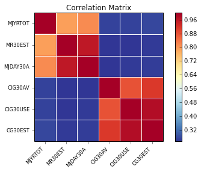

```python
#draw correlation matrix chart
corr_matrix = np.corrcoef(dc.transpose())
sm.graphics.plot_corr(corr_matrix, xnames=list(dc.columns.values))
plt.show()
```

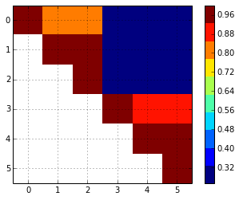

```python
# mask to get the upper diagnal area only
from matplotlib import cm as CM
mask =  np.tri(corr_matrix.shape[0], k=-1)
corr_matrix2 = np.ma.array(corr_matrix, mask=mask) # mask out the lower triangle
fig = plt.figure(figsize = (6, 4))
ax1 = fig.add_subplot(111)
cmap = CM.get_cmap('jet', 10) # jet doesn't have white color
cmap.set_bad('w') # default value is 'k'
t = ax1.imshow(corr_matrix2, interpolation="nearest", cmap=cmap)
cbar = plt.colorbar(t)
ax1.grid(True)
plt.show()
```

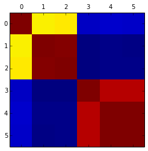

```python
plt.matshow(dc.corr(method='spearman'))
#colorbar()
```

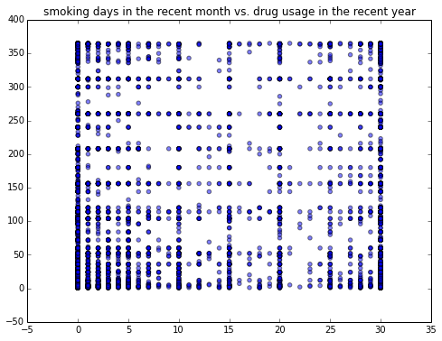

```python
# a scatter plot for smoking days in the recent month vs. drug usage in the recent year
# survey feature (data is clustered)
fig = plt.figure(figsize = (8, 6))
plt.scatter(cguse, mjtot,  alpha=0.5)
plt.title("smoking days in the recent month vs. drug usage in the recent year")
plt.show()
```

```python
#add smoking measure in the model, keep the age group
#note that both predictors are continuous variables
y, X = dmatrices('MJDEP ~ C(CATAG3) + MJYRTOT + CIG30USE',
                  df3, return_type="dataframe")
X = X.rename(columns = {'C(CATAG3)[T.2]':'age18-25',
                        'C(CATAG3)[T.3]':'age26-34',
                        'C(CATAG3)[T.4]':'age35-49',
                        'C(CATAG3)[T.5]':'age50 above'})
y = np.ravel(y)
# instantiate a logistic regression model, and fit with X and y
model = LogisticRegression()
model = model.fit(X, y)

# check the accuracy on the training set
model.score(X, y) #0.84898836868341321
y.mean()          #0.1482748509432118
import statsmodels.api as sm
mdep=sm.Logit(y, X).fit()
print mdep.summary()
# the results show added CIG30USE is not a significant input
# note that the baseline for age group are age12-17, which has the most impact towards drug denpendence.
```

```
Optimization terminated successfully.
         Current function value: 0.382753
         Iterations 7
                           Logit Regression Results
==============================================================================
Dep. Variable:                      y   No. Observations:                10231
Model:                          Logit   Df Residuals:                    10224
Method:                           MLE   Df Model:                            6
Date:                Sat, 01 Aug 2015   Pseudo R-squ.:                 0.08804
Time:                        09:40:21   Log-Likelihood:                -3915.9
converged:                       True   LL-Null:                       -4294.0
                                        LLR p-value:                4.645e-160
===============================================================================
                  coef    std err          z      P>|z|      [95.0% Conf. Int.]
-------------------------------------------------------------------------------
Intercept      -1.7426      0.056    -30.976      0.000        -1.853    -1.632
age18-25       -0.8581      0.067    -12.883      0.000        -0.989    -0.728
age26-34       -1.4872      0.126    -11.821      0.000        -1.734    -1.241
age35-49       -1.5567      0.148    -10.517      0.000        -1.847    -1.267
age50 above    -1.4138      0.206     -6.877      0.000        -1.817    -1.011
MJYRTOT         0.0050      0.000     22.223      0.000         0.005     0.005
CIG30USE        0.0011      0.002      0.436      0.663        -0.004     0.006
===============================================================================
```

The z-value is the regression coefficient divided by its standard error. If the z-value is too big in magnitude (i.e., either too positive or too negative), it indicates that the corresponding true regression coefficient is not 0 and the corresponding X-variable matters. A good rule of thumb is to use a cut-off value of 2 which approximately corresponds to a two-sided hypothesis test with a significance level of =0.05.

```python
#Replace with categorical predictors, keep the age group
y, X = dmatrices('MJDEP ~ C(CATAG3) + C(MR30EST) + C(CIG30AV) ',
                  df3, return_type="dataframe")
X = X.rename(columns = {'C(CATAG3)[T.2]':'age18-25',
                        'C(CATAG3)[T.3]':'age26-34',
                        'C(CATAG3)[T.4]':'age35-49',
                        'C(CATAG3)[T.5]':'age50 above',
                        'C(MR30EST)[T.1]':'MJ 1-2 days',
                        'C(MR30EST)[T.2]':'MJ 3-5 days',
                        'C(MR30EST)[T.3]':'MJ 6-9 days',
                        'C(MR30EST)[T.4]':'MJ 10-19 days',
                        'C(MR30EST)[T.5]':'MJ 20-29 days',
                        'C(MR30EST)[T.6]':'MJ 30 days',
                        'C(CIG30AV)[T.1]':'<1 ciga/day',
                        'C(CIG30AV)[T.2]':'=1 ciga/day',
                        'C(CIG30AV)[T.3]':'2-5 ciga/day',
                        'C(CIG30AV)[T.4]':'6-15 ciga/day',
                        'C(CIG30AV)[T.5]':'16-25 ciga/day',
                        'C(CIG30AV)[T.6]':'26-35 ciga/day',
                        'C(CIG30AV)[T.7]':'>35 ciga/day'})
y = np.ravel(y)
# instantiate a logistic regression model, and fit with X and y
model = LogisticRegression()
model = model.fit(X, y)

# check the accuracy on the training set
#model.score(X, y) #0.85201837552536408
#y.mean()          #0.1482748509432118
import statsmodels.api as sm
mdep=sm.Logit(y, X).fit()
print mdep.summary()
```

```
Optimization terminated successfully.
         Current function value: 0.388445
         Iterations 7
                           Logit Regression Results
==============================================================================
Dep. Variable:                      y   No. Observations:                10231
Model:                          Logit   Df Residuals:                    10213
Method:                           MLE   Df Model:                           17
Date:                Sat, 01 Aug 2015   Pseudo R-squ.:                 0.07448
Time:                        10:04:09   Log-Likelihood:                -3974.2
converged:                       True   LL-Null:                       -4294.0
                                        LLR p-value:                5.666e-125
==================================================================================
                     coef    std err          z      P>|z|      [95.0% Conf. Int.]
----------------------------------------------------------------------------------
Intercept         -1.7620      0.067    -26.282      0.000        -1.893    -1.631
age18-25          -0.8190      0.066    -12.377      0.000        -0.949    -0.689
age26-34          -1.4385      0.126    -11.448      0.000        -1.685    -1.192
age35-49          -1.5553      0.150    -10.357      0.000        -1.850    -1.261
age50 above       -1.4281      0.207     -6.905      0.000        -1.833    -1.023
MJ 1-2 days        0.0428      0.106      0.403      0.687        -0.165     0.251
MJ 3-5 days        0.4672      0.106      4.400      0.000         0.259     0.675
MJ 6-9 days        1.0218      0.128      8.005      0.000         0.772     1.272
MJ 10-19 days      0.9845      0.101      9.740      0.000         0.786     1.183
MJ 20-29 days      1.1378      0.090     12.643      0.000         0.961     1.314
MJ 30 days         1.2158      0.093     13.104      0.000         1.034     1.398
<1 ciga/day        0.4525      0.108      4.202      0.000         0.241     0.664
=1 ciga/day        0.2947      0.113      2.610      0.009         0.073     0.516
2-5 ciga/day       0.4045      0.081      5.016      0.000         0.246     0.563
6-15 ciga/day      0.1213      0.099      1.221      0.222        -0.073     0.316
16-25 ciga/day     0.2317      0.130      1.779      0.075        -0.024     0.487
26-35 ciga/day     0.8805      0.235      3.751      0.000         0.420     1.341
>35 ciga/day       0.8716      0.359      2.427      0.015         0.168     1.575
==================================================================================
```

```python
y, X = dmatrices('MJDEP ~ C(CATAG3) + MJYRTOT + C(MR30EST)+ C(CIG30AV)',
                  df3, return_type="dataframe")
#print X.columns
X = X.rename(columns = {'C(CATAG3)[T.2]':'age18-25',
                        'C(CATAG3)[T.3]':'age26-34',
                        'C(CATAG3)[T.4]':'age35-49',
                        'C(CATAG3)[T.5]':'age50 above',
                        'C(MR30EST)[T.1]':'MJ 1-2 days',
                        'C(MR30EST)[T.2]':'MJ 3-5 days',
                        'C(MR30EST)[T.3]':'MJ 6-9 days',
                        'C(MR30EST)[T.4]':'MJ 10-19 days',
                        'C(MR30EST)[T.5]':'MJ 20-29 days',
                        'C(MR30EST)[T.6]':'MJ 30 days',
                        'C(CIG30AV)[T.1]':'<1 ciga/day',
                        'C(CIG30AV)[T.2]':'=1 ciga/day',
                        'C(CIG30AV)[T.3]':'2-5 ciga/day',
                        'C(CIG30AV)[T.4]':'6-15 ciga/day',
                        'C(CIG30AV)[T.5]':'16-25 ciga/day',
                        'C(CIG30AV)[T.6]':'26-35 ciga/day',
                        'C(CIG30AV)[T.7]':'>35 ciga/day'})
import statsmodels.api as sm
mdep=sm.Logit(y, X).fit()
print mdep.summary()
```

```
Optimization terminated successfully.
         Current function value: 0.378982
         Iterations 7
                           Logit Regression Results
==============================================================================
Dep. Variable:                  MJDEP   No. Observations:                10231
Model:                          Logit   Df Residuals:                    10212
Method:                           MLE   Df Model:                           18
Date:                Sat, 01 Aug 2015   Pseudo R-squ.:                 0.09703
Time:                        10:05:07   Log-Likelihood:                -3877.4
converged:                       True   LL-Null:                       -4294.0
                                        LLR p-value:                2.620e-165
==================================================================================
                     coef    std err          z      P>|z|      [95.0% Conf. Int.]
----------------------------------------------------------------------------------
Intercept         -1.9510      0.070    -28.031      0.000        -2.087    -1.815
age18-25          -0.8610      0.067    -12.803      0.000        -0.993    -0.729
age26-34          -1.4568      0.127    -11.494      0.000        -1.705    -1.208
age35-49          -1.5625      0.152    -10.303      0.000        -1.860    -1.265
age50 above       -1.4022      0.208     -6.737      0.000        -1.810    -0.994
MJ 1-2 days        0.0373      0.107      0.347      0.728        -0.173     0.248
MJ 3-5 days        0.2235      0.109      2.043      0.041         0.009     0.438
MJ 6-9 days        0.4145      0.138      2.994      0.003         0.143     0.686
MJ 10-19 days      0.4001      0.110      3.622      0.000         0.184     0.617
MJ 20-29 days      0.0826      0.118      0.703      0.482        -0.148     0.313
MJ 30 days        -0.1394      0.134     -1.038      0.299        -0.403     0.124
<1 ciga/day        0.4437      0.109      4.066      0.000         0.230     0.658
=1 ciga/day        0.2807      0.114      2.461      0.014         0.057     0.504
2-5 ciga/day       0.3222      0.082      3.941      0.000         0.162     0.482
6-15 ciga/day      0.0101      0.101      0.101      0.920        -0.187     0.207
16-25 ciga/day     0.1106      0.132      0.840      0.401        -0.147     0.369
26-35 ciga/day     0.7648      0.240      3.189      0.001         0.295     1.235
>35 ciga/day       0.7209      0.369      1.956      0.050        -0.001     1.443
MJYRTOT            0.0050      0.000     13.944      0.000         0.004     0.006
==================================================================================
```

```python
# after adding the MJYRTOT, 3 levels in CIG30AV turned not to be significant (with p >.05)
# since we try to detect the impact to the drug dependence due to smoking and
# light smoking have less relavent association, we would replace CIG30AV with CG30EST in this model
y, X = dmatrices('MJDEP ~ C(CATAG3) + MJYRTOT + C(MR30EST)+ C(CG30EST)',
                  df3, return_type="dataframe")
#print X.columns
X = X.rename(columns = {'C(CATAG3)[T.2]':'age18-25',
                        'C(CATAG3)[T.3]':'age26-34',
                        'C(CATAG3)[T.4]':'age35-49',
                        'C(CATAG3)[T.5]':'age50 above',
                        'C(MR30EST)[T.1]':'MJ 1-2 days',
                        'C(MR30EST)[T.2]':'MJ 3-5 days',
                        'C(MR30EST)[T.3]':'MJ 6-9 days',
                        'C(MR30EST)[T.4]':'MJ 10-19 days',
                        'C(MR30EST)[T.5]':'MJ 20-29 days',
                        'C(MR30EST)[T.6]':'MJ 30 days',
                        'C(CG30EST)[T.1]':'CG 1-2 days',
                        'C(CG30EST)[T.2]':'CG 3-5 days',
                        'C(CG30EST)[T.3]':'CG 6-9 days',
                        'C(CG30EST)[T.4]':'CG 10-19 days',
                        'C(CG30EST)[T.5]':'CG 20-29 days',
                        'C(CG30EST)[T.6]':'CG 30 days'})

import statsmodels.api as sm
mdep=sm.Logit(y, X).fit()
print mdep.summary()
# result shows a everyday smoking is not significant.
# we did the crosstab above which shows this smoking group own more both dependence and non-dependence cases,
# however the ratio between dependence and non-dependence are much smaller than other smoking groups
```

```
Optimization terminated successfully.
         Current function value: 0.378628
         Iterations 7
                           Logit Regression Results
==============================================================================
Dep. Variable:                  MJDEP   No. Observations:                10231
Model:                          Logit   Df Residuals:                    10213
Method:                           MLE   Df Model:                           17
Date:                Sat, 01 Aug 2015   Pseudo R-squ.:                 0.09787
Time:                        10:13:50   Log-Likelihood:                -3873.7
converged:                       True   LL-Null:                       -4294.0
                                        LLR p-value:                1.049e-167
=================================================================================
                    coef    std err          z      P>|z|      [95.0% Conf. Int.]
---------------------------------------------------------------------------------
Intercept        -1.9597      0.070    -28.134      0.000        -2.096    -1.823
age18-25         -0.8580      0.067    -12.763      0.000        -0.990    -0.726
age26-34         -1.4333      0.126    -11.368      0.000        -1.680    -1.186
age35-49         -1.4907      0.148    -10.048      0.000        -1.782    -1.200
age50 above      -1.3335      0.206     -6.488      0.000        -1.736    -0.931
MJ 1-2 days       0.0331      0.108      0.307      0.759        -0.178     0.244
MJ 3-5 days       0.2092      0.110      1.910      0.056        -0.005     0.424
MJ 6-9 days       0.4053      0.138      2.927      0.003         0.134     0.677
MJ 10-19 days     0.3995      0.110      3.619      0.000         0.183     0.616
MJ 20-29 days     0.0824      0.118      0.701      0.483        -0.148     0.313
MJ 30 days       -0.1006      0.134     -0.749      0.454        -0.364     0.163
CG 1-2 days       0.2622      0.115      2.283      0.022         0.037     0.487
CG 3-5 days       0.5524      0.118      4.678      0.000         0.321     0.784
CG 6-9 days       0.6536      0.176      3.711      0.000         0.308     0.999
CG 10-19 days     0.3824      0.119      3.211      0.001         0.149     0.616
CG 20-29 days     0.3773      0.111      3.399      0.001         0.160     0.595
CG 30 days        0.0279      0.082      0.342      0.732        -0.132     0.188
MJYRTOT           0.0050      0.000     13.973      0.000         0.004     0.006
=================================================================================
```

```python
#print df3[df3['MJDEP']==0].groupby('MR30EST').count()
#why after adding the MJYRTOT, the MJ20-30 became non-significant?
```

```python
# add health condition
y, X = dmatrices('MJDEP ~ C(CATAG3) + C(HEALTH2) + MJYRTOT + C(MR30EST) + C(CG30EST)',
                  df3, return_type="dataframe")
#print X.columns
X = X.rename(columns = {'C(CATAG3)[T.2]':'age18-25',
                        'C(CATAG3)[T.3]':'age26-34',
                        'C(CATAG3)[T.4]':'age35-49',
                        'C(CATAG3)[T.5]':'age50 above',
                        'C(HEALTH2)[T.2]':'very good',
                        'C(HEALTH2)[T.3]':'good',
                        'C(HEALTH2)[T.4]':'fair/poor',
                        'C(MR30EST)[T.1]':'MJ 1-2 days',
                        'C(MR30EST)[T.2]':'MJ 3-5 days',
                        'C(MR30EST)[T.3]':'MJ 6-9 days',
                        'C(MR30EST)[T.4]':'MJ 10-19 days',
                        'C(MR30EST)[T.5]':'MJ 20-29 days',
                        'C(MR30EST)[T.6]':'MJ 30 days',
                        'C(CG30EST)[T.1]':'CG 1-2 days',
                        'C(CG30EST)[T.2]':'CG 3-5 days',
                        'C(CG30EST)[T.3]':'CG 6-9 days',
                        'C(CG30EST)[T.4]':'CG 10-19 days',
                        'C(CG30EST)[T.5]':'CG 20-29 days',
                        'C(CG30EST)[T.6]':'CG 30 days'})

import statsmodels.api as sm
mdep=sm.Logit(y, X).fit()
print mdep.summary()
```

```
Optimization terminated successfully.
         Current function value: 0.377250
         Iterations 7
                           Logit Regression Results
==============================================================================
Dep. Variable:                  MJDEP   No. Observations:                10231
Model:                          Logit   Df Residuals:                    10210
Method:                           MLE   Df Model:                           20
Date:                Sat, 01 Aug 2015   Pseudo R-squ.:                  0.1012
Time:                        10:51:05   Log-Likelihood:                -3859.6
converged:                       True   LL-Null:                       -4294.0
                                        LLR p-value:                3.565e-171
=================================================================================
                    coef    std err          z      P>|z|      [95.0% Conf. Int.]
---------------------------------------------------------------------------------
Intercept        -2.2004      0.092    -24.034      0.000        -2.380    -2.021
age18-25         -0.8537      0.067    -12.671      0.000        -0.986    -0.722
age26-34         -1.4459      0.126    -11.441      0.000        -1.694    -1.198
age35-49         -1.5412      0.149    -10.320      0.000        -1.834    -1.249
age50 above      -1.4169      0.207     -6.829      0.000        -1.824    -1.010
very good         0.2629      0.082      3.193      0.001         0.102     0.424
good              0.3814      0.088      4.334      0.000         0.209     0.554
fair/poor         0.5529      0.118      4.688      0.000         0.322     0.784
MJ 1-2 days       0.0467      0.108      0.433      0.665        -0.165     0.258
MJ 3-5 days       0.2120      0.110      1.931      0.053        -0.003     0.427
MJ 6-9 days       0.3907      0.139      2.810      0.005         0.118     0.663
MJ 10-19 days     0.3987      0.111      3.605      0.000         0.182     0.615
MJ 20-29 days     0.0902      0.118      0.767      0.443        -0.140     0.321
MJ 30 days       -0.0980      0.135     -0.729      0.466        -0.362     0.166
CG 1-2 days       0.2583      0.115      2.244      0.025         0.033     0.484
CG 3-5 days       0.5354      0.118      4.527      0.000         0.304     0.767
CG 6-9 days       0.6267      0.176      3.552      0.000         0.281     0.972
CG 10-19 days     0.3458      0.119      2.895      0.004         0.112     0.580
CG 20-29 days     0.3238      0.112      2.897      0.004         0.105     0.543
CG 30 days       -0.0459      0.083     -0.553      0.580        -0.209     0.117
MJYRTOT           0.0050      0.000     13.873      0.000         0.004     0.006
=================================================================================
```

```python
# add eductional level
y, X = dmatrices('MJDEP ~ C(HEALTH2) + C(EDUCCAT2) + MJYRTOT + C(MR30EST)+ C(CG30EST)',
                  df3, return_type="dataframe")
#print X.columns
X = X.rename(columns = {'C(HEALTH2)[T.2]':'very good',
                        'C(HEALTH2)[T.3]':'good',
                        'C(HEALTH2)[T.4]':'fair/poor',
                        'C(EDUCCAT2)[T.2]':'high school >18yr old',
                        'C(EDUCCAT2)[T.3]':'college',
                        'C(EDUCCAT2)[T.4]':'graduate',
                        'C(EDUCCAT2)[T.5]':'12-17y old',
                        'C(MR30EST)[T.1]':'MJ 1-2 days',
                        'C(MR30EST)[T.2]':'MJ 3-5 days',
                        'C(MR30EST)[T.3]':'MJ 6-9 days',
                        'C(MR30EST)[T.4]':'MJ 10-19 days',
                        'C(MR30EST)[T.5]':'MJ 20-29 days',
                        'C(MR30EST)[T.6]':'MJ 30 days',
                        'C(CG30EST)[T.1]':'CG 1-2 days',
                        'C(CG30EST)[T.2]':'CG 3-5 days',
                        'C(CG30EST)[T.3]':'CG 6-9 days',
                        'C(CG30EST)[T.4]':'CG 10-19 days',
                        'C(CG30EST)[T.5]':'CG 20-29 days',
                        'C(CG30EST)[T.6]':'CG 30 days'})

import statsmodels.api as sm
mdep=sm.Logit(y, X).fit()
print mdep.summary()
```

```
Optimization terminated successfully.
         Current function value: 0.378472
         Iterations 7
                           Logit Regression Results
==============================================================================
Dep. Variable:                  MJDEP   No. Observations:                10231
Model:                          Logit   Df Residuals:                    10210
Method:                           MLE   Df Model:                           20
Date:                Sat, 01 Aug 2015   Pseudo R-squ.:                 0.09824
Time:                        11:22:34   Log-Likelihood:                -3872.1
converged:                       True   LL-Null:                       -4294.0
                                        LLR p-value:                7.335e-166
=========================================================================================
                            coef    std err          z      P>|z|      [95.0% Conf. Int.]
-----------------------------------------------------------------------------------------
Intercept                -2.9099      0.118    -24.575      0.000        -3.142    -2.678
very good                 0.2541      0.082      3.084      0.002         0.093     0.416
good                      0.3319      0.088      3.772      0.000         0.159     0.504
fair/poor                 0.4137      0.117      3.543      0.000         0.185     0.643
high school >18yr old    -0.2224      0.098     -2.273      0.023        -0.414    -0.031
college                  -0.2080      0.100     -2.082      0.037        -0.404    -0.012
graduate                 -0.6890      0.138     -4.981      0.000        -0.960    -0.418
12-17y old                0.7460      0.096      7.745      0.000         0.557     0.935
MJ 1-2 days               0.0389      0.108      0.361      0.718        -0.172     0.250
MJ 3-5 days               0.1935      0.110      1.765      0.078        -0.021     0.408
MJ 6-9 days               0.3847      0.139      2.773      0.006         0.113     0.657
MJ 10-19 days             0.3907      0.110      3.550      0.000         0.175     0.606
MJ 20-29 days             0.0845      0.117      0.721      0.471        -0.145     0.314
MJ 30 days               -0.1160      0.134     -0.868      0.386        -0.378     0.146
CG 1-2 days               0.2918      0.115      2.534      0.011         0.066     0.518
CG 3-5 days               0.5752      0.118      4.866      0.000         0.343     0.807
CG 6-9 days               0.6346      0.176      3.607      0.000         0.290     0.979
CG 10-19 days             0.3559      0.119      2.984      0.003         0.122     0.590
CG 20-29 days             0.3214      0.111      2.886      0.004         0.103     0.540
CG 30 days               -0.1369      0.083     -1.648      0.099        -0.300     0.026
MJYRTOT                   0.0049      0.000     13.886      0.000         0.004     0.006
=========================================================================================
```

```python
#df3.groupby(['CATAG3','EDUCCAT2']).size().groupby(level=1).max()
#df3.groupby(['CATAG3','EDUCCAT2']).size().reset_index().groupby('EDUCCAT2')[[0]].max()
df3.groupby(['CATAG3','EDUCCAT2']).size()
```

```
CATAG3  EDUCCAT2
1       5           2448
2       1           1006
        2           1955
        3           1942
        4            661
3       1            164
        2            280
        3            307
        4            337
4       1            122
        2            237
        3            214
        4            217
5       1             49
        2            116
        3             90
        4             86
dtype: int64
```

```python
y, X = dmatrices('MJDEP ~ C(CATAG3) + C(HEALTH2) +C(NEWRACE2) + MJYRTOT + C(MR30EST)+ C(CG30EST)',
                  df3, return_type="dataframe")
#print X.columns
X = X.rename(columns = {'C(CATAG3)[T.2]':'age18-25',
                        'C(CATAG3)[T.3]':'age26-34',
                        'C(CATAG3)[T.4]':'age35-49',
                        'C(CATAG3)[T.5]':'age50 above',
                        'C(HEALTH2)[T.2]':'very good',
                        'C(HEALTH2)[T.3]':'good',
                        'C(HEALTH2)[T.4]':'fair/poor',
                        'C(NEWRACE2)[T.2]':'black',
                        'C(NEWRACE2)[T.3]':'native america',
                        'C(NEWRACE2)[T.4]':'pacific',
                        'C(NEWRACE2)[T.5]':'asian',
                        'C(NEWRACE2)[T.6]':'multi races',
                        'C(NEWRACE2)[T.7]':'hispanic',
                        'C(MR30EST)[T.1]':'MJ 1-2 days',
                        'C(MR30EST)[T.2]':'MJ 3-5 days',
                        'C(MR30EST)[T.3]':'MJ 6-9 days',
                        'C(MR30EST)[T.4]':'MJ 10-19 days',
                        'C(MR30EST)[T.5]':'MJ 20-29 days',
                        'C(MR30EST)[T.6]':'MJ 30 days',
                        'C(CG30EST)[T.1]':'CG 1-2 days',
                        'C(CG30EST)[T.2]':'CG 3-5 days',
                        'C(CG30EST)[T.3]':'CG 6-9 days',
                        'C(CG30EST)[T.4]':'CG 10-19 days',
                        'C(CG30EST)[T.5]':'CG 20-29 days',
                        'C(CG30EST)[T.6]':'CG 30 days'})

import statsmodels.api as sm
mdep=sm.Logit(y, X).fit()
print mdep.summary()
```

[output not shown]

```python
#print sm.Logit(y, X).fit().conf_int()
```

```python
# odds ratios only
#print np.exp(sm.Logit(y, X).fit().params)
# odds ratios and 95% CI
pd.set_option('max_rows',30)
params = sm.Logit(y, X).fit().params
conf = sm.Logit(y, X).fit().conf_int()
conf['OR'] = params
conf.columns = ['2.5%', '97.5%','OR']
ort = np.exp(conf)
print ort
```

```
Optimization terminated successfully.
         Current function value: 0.376172
         Iterations 7
Optimization terminated successfully.
         Current function value: 0.376172
         Iterations 7
                    2.5%     97.5%        OR
Intercept       0.080933  0.118320  0.097857
age18-25        0.375940  0.490012  0.429203
age26-34        0.186072  0.305883  0.238572
age35-49        0.164909  0.296649  0.221179
age50 above     0.168336  0.380768  0.253174
very good       1.115326  1.541119  1.311049
good            1.218436  1.721196  1.448160
fair/poor       1.322972  2.104699  1.668669
black           1.045026  1.455718  1.233395
native america  1.052477  2.269195  1.545404
pacific         1.050254  3.684618  1.967177
asian           0.697618  1.621624  1.063614
multi race      0.964679  1.583904  1.236106
hispanic        1.141746  1.565182  1.336803
MJ 1-2 days     0.851474  1.300144  1.052159
MJ 3-5 days     0.986994  1.519137  1.224492
MJ 6-9 days     1.118958  1.932021  1.470323
MJ 10-19 days   1.201043  1.853386  1.491977
MJ 20-29 days   0.886090  1.404373  1.115527
MJ 30 days      0.708202  1.198500  0.921293
CG 1-2 days     1.040445  1.637358  1.305213
CG 3-5 days     1.364333  2.171594  1.721272
CG 6-9 days     1.318271  2.635034  1.863783
CG 10-19 days   1.123454  1.796050  1.420486
CG 20-29 days   1.140640  1.771099  1.421333
CG 30 days      0.851012  1.184865  1.004159
MJYRTOT         1.004198  1.005603  1.004900
```

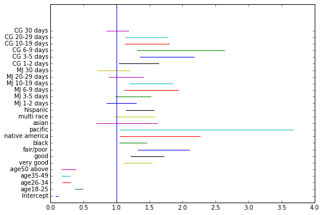

```python
# create a forest plot
ort_ary = ort[['2.5%','97.5%']].values
ort_name = list(X.columns.values)
#type(ort_ary)
#ort_ary[0]
fig = plt.figure(figsize = (8, 6))
i=0
for point in ort_ary:
    i+=1
    plt.plot(point,(i,i))
plt.axvline(x=1.0)
ym=(range(1,len(ort_name)))
#LABELS = ["age12-17", "age18-25", "age26-34","age35-49'","age50 above"]
plt.yticks(ym, ort_name)
plt.show()
```

```python
#Limits -
#standard coefficient/beta coefficient
#survey weight/representative factor
#forest plot
#correlation matrix
#model selection stepwise/backward/forward
#goodness of fit criteria (lower Akaike information criterion - AIC, AICC, SBC, SBIC, BIC)
```

```python
#score the model
```

```python
# drug dependence = age_group + drug_used_days_last_year + smoking_days_recent_month
y, X = dmatrices('MJDEP ~ C(CATAG3) + MJYRTOT + C(CG30EST)',
                  df3, return_type="dataframe")
#print X.columns

X = X.rename(columns = {'C(CATAG3)[T.2]':'age18-25',
                        'C(CATAG3)[T.3]':'age26-34',
                        'C(CATAG3)[T.4]':'age35-49',
                        'C(CATAG3)[T.5]':'age50 above',
                        'C(CG30EST)[T.1]':'CG 1-2 days',
                        'C(CG30EST)[T.2]':'CG 3-5 days',
                        'C(CG30EST)[T.3]':'CG 6-9 days',
                        'C(CG30EST)[T.4]':'CG 10-19 days',
                        'C(CG30EST)[T.5]':'CG 20-29 days',
                        'C(CG30EST)[T.6]':'CG 30 days'})
import statsmodels.api as sm
mdep=sm.Logit(y, X).fit()
print mdep.summary()
```

```
Optimization terminated successfully.
         Current function value: 0.380112
         Iterations 7
                           Logit Regression Results
==============================================================================
Dep. Variable:                  MJDEP   No. Observations:                10231
Model:                          Logit   Df Residuals:                    10219
Method:                           MLE   Df Model:                           11
Date:                Thu, 30 Jul 2015   Pseudo R-squ.:                 0.09434
Time:                        05:07:43   Log-Likelihood:                -3888.9
converged:                       True   LL-Null:                       -4294.0
                                        LLR p-value:                1.252e-166
=================================================================================
                    coef    std err          z      P>|z|      [95.0% Conf. Int.]
---------------------------------------------------------------------------------
Intercept        -1.8602      0.060    -30.898      0.000        -1.978    -1.742
age18-25         -0.8725      0.067    -13.024      0.000        -1.004    -0.741
age26-34         -1.4574      0.126    -11.575      0.000        -1.704    -1.211
age35-49         -1.5046      0.148    -10.147      0.000        -1.795    -1.214
age50 above      -1.3508      0.206     -6.568      0.000        -1.754    -0.948
CG 1-2 days       0.2815      0.114      2.459      0.014         0.057     0.506
CG 3-5 days       0.5846      0.117      4.980      0.000         0.355     0.815
CG 6-9 days       0.6957      0.175      3.965      0.000         0.352     1.040
CG 10-19 days     0.4243      0.118      3.582      0.000         0.192     0.656
CG 20-29 days     0.4064      0.111      3.672      0.000         0.189     0.623
CG 30 days        0.0225      0.082      0.276      0.783        -0.137     0.182
MJYRTOT           0.0049      0.000     21.802      0.000         0.004     0.005
=================================================================================
```

```python
# divide data into training and testing sets
X_train, X_test, y_train, y_test = train_test_split(X, y, test_size=0.3, random_state=0)
y_train = np.ravel(y_train)
y_test = np.ravel(y_test)
model2 = LogisticRegression()
model2.fit(X_train, y_train)
```

```
LogisticRegression(C=1.0, class_weight=None, dual=False, fit_intercept=True,
          intercept_scaling=1, penalty='l2', random_state=None, tol=0.0001)
```

```python
model2.score(X_train, y_train)
```

```
0.84974165619326913
```

```python
# predict class labels by using the testing set
predicted = model2.predict(X_test)
print predicted
```

```
[ 0.  0.  0. ...,  0.  0.  0.]
```

```python
# generate class probabilities
probs = model2.predict_proba(X_test)
print probs
```

```
[[ 0.71877707  0.28122293]
 [ 0.91653431  0.08346569]
 [ 0.85698345  0.14301655]
 ...,
 [ 0.90200701  0.09799299]
 [ 0.8741845   0.1258155 ]
 [ 0.89921138  0.10078862]]
```

```python
# generate evaluation metrics
print metrics.accuracy_score(y_test, predicted)
print metrics.roc_auc_score(y_test, probs[:, 1])
```

```
0.85667752443
0.722808728378
```

```python
#The accuracy is 85%, which is the same as the training results.
# generate confusion matrix and a classification report with other metrics.
print metrics.confusion_matrix(y_test, predicted)
print metrics.classification_report(y_test, predicted)
```

```
[[2612   14]
 [ 426   18]]
             precision    recall  f1-score   support

        0.0       0.86      0.99      0.92      2626
        1.0       0.56      0.04      0.08       444

avg / total       0.82      0.86      0.80      3070
```

```python
# evaluate the model using 10-fold cross-validation
y = np.ravel(y)
scores = cross_val_score(LogisticRegression(), X, y, scoring='accuracy', cv=10)
print scores
print scores.mean()
```

```
[ 0.84375     0.84863281  0.85839844  0.85546875  0.85434995  0.85532747
  0.8514174   0.85225049  0.84833659  0.84931507]
0.85172469718
```

```python
model2.predict_proba(np.array([1, 1, 0, 0, 0, 0, 0, 1, 0, 0, 0, 300]))
```

```
array([[ 0.63597061,  0.36402939]])
```

```python
X[:2]
```

|  | Intercept | age18-25 | age26-34 | age35-49 | age50 above | CG 1-2 days | CG 3-5 days | CG 6-9 days | CG 10-19 days | CG 20-29 days | CG 30 days | MJYRTOT |
| --- | --- | --- | --- | --- | --- | --- | --- | --- | --- | --- | --- | --- |
| 1 | 1 | 1 | 0 | 0 | 0 | 0 | 0 | 0 | 0 | 0 | 0 | 365 |
| 5 | 1 | 1 | 0 | 0 | 0 | 0 | 0 | 0 | 0 | 1 | 0 | 24 |